# 第6週 探索的データ分析 - EDA

### データの確認

```r
df_environment
```

| country | iso2c | iso3c | year | status | lastupdated | co2pcap | forest | renewable | fossil | nuclear | region | capital | longitude | latitude | income | lending |
| --- | --- | --- | --- | --- | --- | --- | --- | --- | --- | --- | --- | --- | --- | --- | --- | --- |
| Afghanistan | AF | AFG | 2014 | NA | 2023-12-18 | 0.28369240 | 1.8527820 | 85.3235490 | NA | NA | South Asia | Kabul | 69.17610 | 34.52280 | Low income | IDA |
| Afghanistan | AF | AFG | 1971 | NA | 2023-12-18 | NA | NA | NA | NA | NA | South Asia | Kabul | 69.17610 | 34.52280 | Low income | IDA |
| Afghanistan | AF | AFG | 2006 | NA | 2023-12-18 | 0.08975691 | 1.8527820 | 70.7557503 | NA | NA | South Asia | Kabul | 69.17610 | 34.52280 | Low income | IDA |
| Afghanistan | AF | AFG | 2013 | NA | 2023-12-18 | 0.29808781 | 1.8527820 | 78.6364081 | NA | NA | South Asia | Kabul | 69.17610 | 34.52280 | Low income | IDA |
| Afghanistan | AF | AFG | 1995 | NA | 2023-12-18 | 0.08878116 | 1.8527820 | 69.0370370 | NA | NA | South Asia | Kabul | 69.17610 | 34.52280 | Low income | IDA |
| Afghanistan | AF | AFG | 2005 | NA | 2023-12-18 | 0.08036113 | 1.8527820 | 74.0618102 | NA | NA | South Asia | Kabul | 69.17610 | 34.52280 | Low income | IDA |
| Afghanistan | AF | AFG | 1997 | NA | 2023-12-18 | 0.07555870 | 1.8527820 | 72.3880597 | NA | NA | South Asia | Kabul | 69.17610 | 34.52280 | Low income | IDA |
| Afghanistan | AF | AFG | 1998 | NA | 2023-12-18 | 0.07126970 | 1.8527820 | 74.4360902 | NA | NA | South Asia | Kabul | 69.17610 | 34.52280 | Low income | IDA |
| Afghanistan | AF | AFG | 1999 | NA | 2023-12-18 | 0.05824684 | 1.8527820 | 73.7226277 | NA | NA | South Asia | Kabul | 69.17610 | 34.52280 | Low income | IDA |
| Afghanistan | AF | AFG | 1996 | NA | 2023-12-18 | 0.08226652 | 1.8527820 | 70.3703704 | NA | NA | South Asia | Kabul | 69.17610 | 34.52280 | Low income | IDA |

[output cut: 990 more lines]

```r
str(df_environment)
```

```
spc_tbl_ [16,758 × 17] (S3: spec_tbl_df/tbl_df/tbl/data.frame)
 $ country    : chr [1:16758] "Afghanistan" "Afghanistan" "Afghanistan" "Afghanistan" ...
 $ iso2c      : chr [1:16758] "AF" "AF" "AF" "AF" ...
 $ iso3c      : chr [1:16758] "AFG" "AFG" "AFG" "AFG" ...
 $ year       : num [1:16758] 2014 1971 2006 2013 1995 ...
 $ status     : logi [1:16758] NA NA NA NA NA NA ...
 $ lastupdated: Date[1:16758], format: "2023-12-18" "2023-12-18" ...
 $ co2pcap    : num [1:16758] 0.2837 NA 0.0898 0.2981 0.0888 ...
 $ forest     : num [1:16758] 1.85 NA 1.85 1.85 1.85 ...
 $ renewable  : num [1:16758] 85.3 NA 70.8 78.6 69 ...
 $ fossil     : num [1:16758] NA NA NA NA NA NA NA NA NA NA ...
 $ nuclear    : num [1:16758] NA NA NA NA NA NA NA NA NA NA ...
 $ region     : chr [1:16758] "South Asia" "South Asia" "South Asia" "South Asia" ...
 $ capital    : chr [1:16758] "Kabul" "Kabul" "Kabul" "Kabul" ...
 $ longitude  : num [1:16758] 69.2 69.2 69.2 69.2 69.2 ...
 $ latitude   : num [1:16758] 34.5 34.5 34.5 34.5 34.5 ...
 $ income     : chr [1:16758] "Low income" "Low income" "Low income" "Low income" ...
 $ lending    : chr [1:16758] "IDA" "IDA" "IDA" "IDA" ...
 - attr(*, "spec")=
  .. cols(
  ..   country = col_character(),
  ..   iso2c = col_character(),
  ..   iso3c = col_character(),
  ..   year = col_double(),
  ..   status = col_logical(),
  ..   lastupdated = col_date(format = ""),
  ..   co2pcap = col_double(),
  ..   forest = col_double(),
  ..   renewable = col_double(),
  ..   fossil = col_double(),
  ..   nuclear = col_double(),
  ..   region = col_character(),
  ..   capital = col_character(),
  ..   longitude = col_double(),
  ..   latitude = col_double(),
  ..   income = col_character(),
  ..   lending = col_character()
  .. )
 - attr(*, "problems")=<externalptr>
```

#### データの数

すべての指標の値があるもののデータ数を、年毎に表示する。

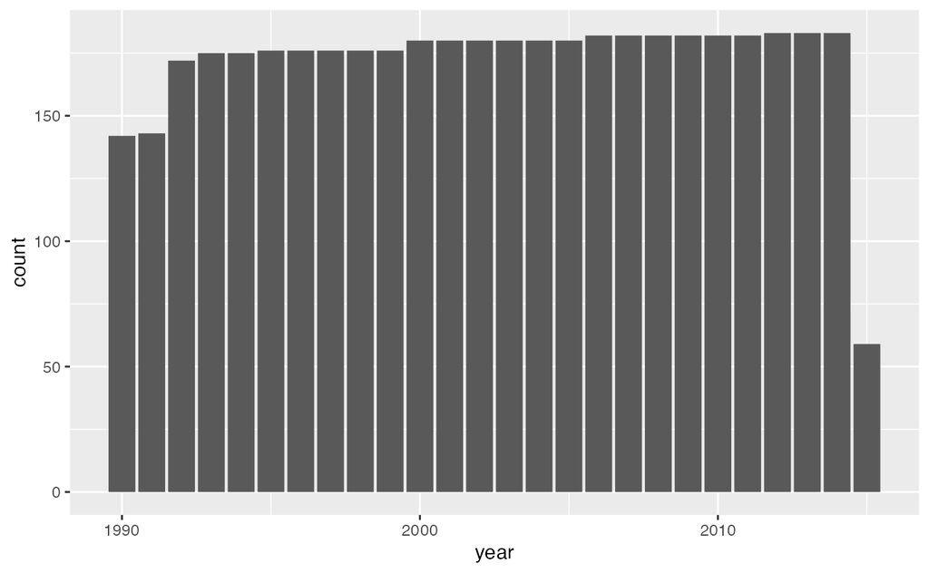

```r
df_env |> drop_na(co2pcap, forest, renewable, fossil, nuclear) |>
  ggplot(aes(year)) + geom_bar()
```

- データは、1990年以降で、すべてのデータが存在するのは、2014年ごろとなる。のちに、それぞれの場合に、個別にみる。

#### 参考

それぞれのデータがどのくらいあるか見たい時は、データを縦長（long data）にして使う次のような方法もある。おおよそ、どの指標のデータが少ないかがわかる。

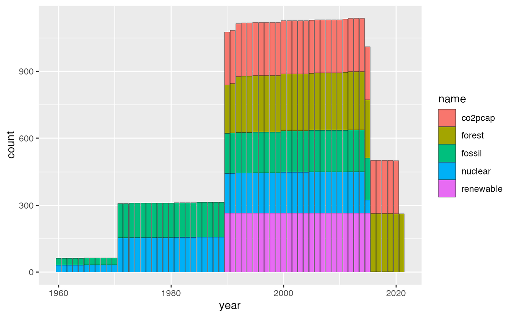

```r
df_env |> pivot_longer(cols = c(co2pcap, forest, renewable, fossil, nuclear)) |>
  drop_na(value) |> ggplot(aes(year, fill = name)) + geom_bar(col = "black", linewidth = 0.1)
```

- すべてのデーが十分あるのは、2014年。ある程度あるのは、2015年、それ以降は、co2pcap と、forest のみ。

#### 変数の選択（selecting）

```r
df_env <- df_environment |>
  select(country, iso2c, year, co2pcap, forest,
         renewable, fossil, nuclear, region, income)
df_env
```

| country | iso2c | year | co2pcap | forest | renewable | fossil | nuclear | region | income |
| --- | --- | --- | --- | --- | --- | --- | --- | --- | --- |
| Afghanistan | AF | 2014 | 0.28369240 | 1.8527820 | 85.3235490 | NA | NA | South Asia | Low income |
| Afghanistan | AF | 1971 | NA | NA | NA | NA | NA | South Asia | Low income |
| Afghanistan | AF | 2006 | 0.08975691 | 1.8527820 | 70.7557503 | NA | NA | South Asia | Low income |
| Afghanistan | AF | 2013 | 0.29808781 | 1.8527820 | 78.6364081 | NA | NA | South Asia | Low income |
| Afghanistan | AF | 1995 | 0.08878116 | 1.8527820 | 69.0370370 | NA | NA | South Asia | Low income |
| Afghanistan | AF | 2005 | 0.08036113 | 1.8527820 | 74.0618102 | NA | NA | South Asia | Low income |
| Afghanistan | AF | 1997 | 0.07555870 | 1.8527820 | 72.3880597 | NA | NA | South Asia | Low income |
| Afghanistan | AF | 1998 | 0.07126970 | 1.8527820 | 74.4360902 | NA | NA | South Asia | Low income |
| Afghanistan | AF | 1999 | 0.05824684 | 1.8527820 | 73.7226277 | NA | NA | South Asia | Low income |
| Afghanistan | AF | 1996 | 0.08226652 | 1.8527820 | 70.3703704 | NA | NA | South Asia | Low income |

[output cut: 990 more lines]

### 変数の相関関係

データを概観するため、授業の最初に見たように、国を選択し、変数の相関関係を見てみる。

```r
df_env |> filter(!(iso2c %in% REGION)) |> # 地域以外（国のみ選択）
  drop_na(co2pcap, forest, renewable, fossil, nuclear) |>
  select(co2pcap, forest, renewable, fossil, nuclear) |> cor()
```

```
             co2pcap     forest  renewable     fossil    nuclear
co2pcap    1.0000000 -0.1832374 -0.4138267  0.3220169  0.1369711
forest    -0.1832374  1.0000000  0.3683177 -0.4234481  0.1131410
renewable -0.4138267  0.3683177  1.0000000 -0.8784240 -0.1851655
fossil     0.3220169 -0.4234481 -0.8784240  1.0000000 -0.2354258
nuclear    0.1369711  0.1131410 -0.1851655 -0.2354258  1.0000000
```

2014年に限定してみる。

```r
df_env |> filter(!(iso2c %in% REGION), year == 2014) |> # 地域以外（国のみ選択）
  drop_na(co2pcap, forest, renewable, fossil, nuclear) |>
  select(co2pcap, forest, renewable, fossil, nuclear) |> cor()
```

```
              co2pcap     forest  renewable     fossil     nuclear
co2pcap    1.00000000 -0.1548686 -0.3902420  0.3056159  0.09178764
forest    -0.15486856  1.0000000  0.3316376 -0.3664743  0.10163594
renewable -0.39024200  0.3316376  1.0000000 -0.8824027 -0.11973317
fossil     0.30561592 -0.3664743 -0.8824027  1.0000000 -0.28368597
nuclear    0.09178764  0.1016359 -0.1197332 -0.2836860  1.00000000
```

### 国と地域

country には、国と地域両方が入っています。地域の iso2c は以下のものです。

```r
REGION <- c("1A", "1W", "4E", "6F", "6N", "6X", "7E", "8S", "A4", "A5",
"A9", "B1", "B2", "B3", "B4", "B6", "B7", "B8", "C4", "C5", "C6",
"C7", "C8", "C9", "D2", "D3", "D4", "D5", "D6", "D7", "EU", "F1",
"F6", "M1", "M2", "N6", "OE", "R6", "S1", "S2", "S3", "S4", "T2",
"T3", "T4", "T5", "T6", "T7", "V1", "V2", "V3", "V4", "XC", "XD",
"XE", "XF", "XG", "XH", "XI", "XJ", "XL", "XM", "XN", "XO", "XP",
"XQ", "XT", "XU", "XY", "Z4", "Z7", "ZB", "ZF", "ZG", "ZH", "ZI",
"ZJ", "ZQ", "ZT")
```

#### 地域のリストを表示

```r
df_env |> filter(iso2c %in% REGION) |> distinct(country, iso2c)
```

| country | iso2c |
| --- | --- |
| Africa Eastern and Southern | ZH |
| Africa Western and Central | ZI |
| Arab World | 1A |
| Caribbean small states | S3 |
| Central Europe and the Baltics | B8 |
| Early-demographic dividend | V2 |
| East Asia & Pacific | Z4 |
| East Asia & Pacific (excluding high income) | 4E |
| East Asia & Pacific (IDA & IBRD countries) | T4 |
| Euro area | XC |

[output cut: 39 more lines]

#### 国名とその地域・所得レベルを表示

```r
df_env |> filter(!(iso2c %in% REGION)) |> distinct(country, iso2c, region, income)
```

| country | iso2c | region | income |
| --- | --- | --- | --- |
| Afghanistan | AF | South Asia | Low income |
| Albania | AL | Europe & Central Asia | Upper middle income |
| Algeria | DZ | Middle East & North Africa | Lower middle income |
| American Samoa | AS | East Asia & Pacific | Upper middle income |
| Andorra | AD | Europe & Central Asia | High income |
| Angola | AO | Sub-Saharan Africa | Lower middle income |
| Antigua and Barbuda | AG | Latin America & Caribbean | High income |
| Argentina | AR | Latin America & Caribbean | Upper middle income |
| Armenia | AM | Europe & Central Asia | Upper middle income |
| Aruba | AW | Latin America & Caribbean | High income |

[output cut: 207 more lines]

### 分析する国のリスト

```r
BRICS <- c("Brazil", "Russian Federation", "India", "China", "South Africa")
```